# ITCM: Classification of Handwritten Digits

### Using Singular Value Decomposition

For each digit $i$, we have a corresponding matrix $A$ in $\mathbb{R}^{n_i\times784}$, where $n_i$ is the number of pictures. Decompose $A$ into $$A = USV^t, $$ where $U$, $V$ are orthogonal matrices, and $S$ is a diagonal matrix with singular values in its diagonal line. Since the first few singular images are more significient than others, Lars Elden selected the first $3$ singular images as bases in the textbook, and our later experiment advised us to select the first $42$ singular images in MNIST database.

```python
U, S, V = LA.svd(x_train3)
```

```
The first 10 singualr values of digit 3 are
 [518.76685 168.29865 142.93507 116.39933 107.81574  89.97174  82.17028
  79.58995  76.80489  72.6178 ] .
```

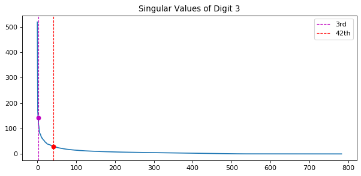

```python
print('The first 10 singualr values of digit 3 are \n',S[:10],'.')
fig = plt.figure(figsize=(9,4), dpi=80)
plt.plot(S)
plt.plot(3, S[2], 'om')
plt.plot(41, S[40], 'or')
plt.axvline(3, color='m', linestyle='dashed', linewidth=1, label='3rd')
plt.axvline(41, color='r', linestyle='dashed', linewidth=1, label='42th')
plt.title('Singular Values of Digit 3')
plt.legend()
plt.show()
```

### Samples of Singular Images

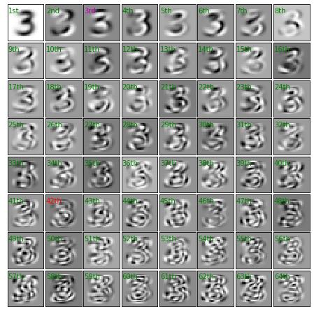

```python
S_ = np.zeros((x_train3.shape[0], x_train3.shape[1]))
fig = plt.figure(figsize=(6, 6))
fig.subplots_adjust(left=0, right=1, bottom=0, top=1, hspace=0.05, wspace=0.05)

for i in range(64):
    A = V[i,]
    ax = fig.add_subplot(8, 8, i + 1, xticks=[], yticks=[])
    ax.imshow(A.reshape(28,28), cmap='Greys', interpolation='nearest')
    if i == 0:
        tmp = str(i+1)+'st'
    elif i == 1:
        tmp = str(i+1)+'nd'
    elif i == 2:
        tmp = str(i+1)+'rd'
    else:
        tmp =str(i+1)+'th'
    if i == 2:
        ax.text(0, 6, tmp, color = 'm')
    elif i == 41:
        ax.text(0, 6, tmp, color = 'r')
    else:
        ax.text(0, 6, tmp, color = 'g')
```

### Take the First Three Singular Images as Lars Elden Did

```python
u = []
s = []
v = []
all_s = []
all_v = []
x_sing = []

for i in range(3):
    U, S, V = LA.svd(x_train_[i])
    S_ = np.zeros((np.array(x_train_)[i].shape[0], np.array(x_train_)[i].shape[1]))
    S_[:np.array(x_train_)[i].shape[1], :np.array(x_train_)[i].shape[1]] = np.diag(S)
    all_s.append(S_)
    all_v.append(V)
    n_component = 3 # Take the first three vectors
    S_ = S_[:, :n_component]
    VT = V[:n_component, :]
    u.append(U)
    s.append(S_)
    v.append(VT)
    A = U.dot(S_.dot(VT))
    x_sing.append(A)
```

### Singular Images in this Choice ($k=3$)

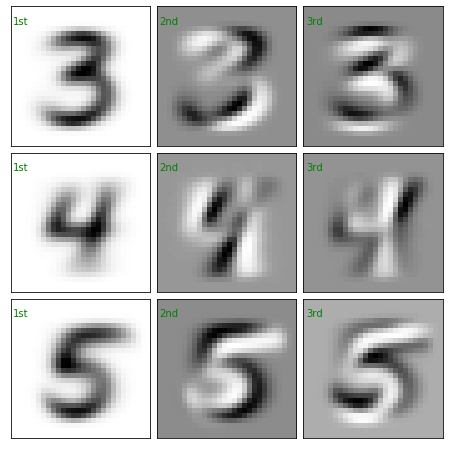

```python
fig = plt.figure(figsize=(6, 6))
fig.subplots_adjust(left=0, right=1,top=1, bottom=0, hspace=0.05, wspace=0.05)

for i in range(9):
    sing_img = np.array(v).reshape(9,784)[i]
    ax = fig.add_subplot(3, 3, i + 1, xticks=[], yticks=[])
    ax.imshow(sing_img.reshape(28,28), cmap='Greys', interpolation='nearest')
    j = i
    while j > 2:
        j -= 3
    if j == 0:
        tmp = str(j+1)+'st'
    elif j == 1:
        tmp = str(j+1)+'nd'
    elif j == 2:
        tmp = str(j+1)+'rd'
    ax.text(0, 3, tmp, color = 'g')
plt.show()
```

## Let's Check the Performance on the Testing Data!

### Derive the Raster Vectors of the Testing Data and Calculate the Residual in Each Digit

The residual of each raster vector $v$ is calculated by $$\text{residual}(v)=|| (I-V_3V_3^t)v||_2, $$ where $V_3 = (v_1,v_2,v_3)$, and $3$ is the parameter of the number of singular images we choose. Classify $v$ into the digit $i$ with the minimal residual. That is, $$\hat{i}=\text{arg}\min_i\{\text{residual}_i(v)\} .$$

```python
def residual(U, z):
    n = U.shape[0]
    return LA.norm(z-U.transpose().dot(U.dot(z))) / LA.norm(z)
```

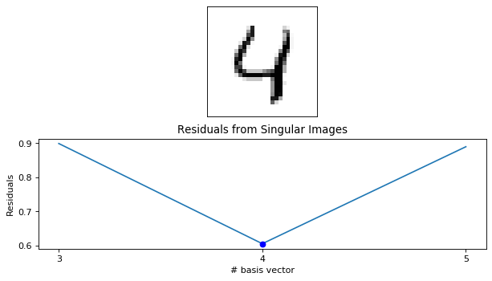

```python
x_test = x_test.reshape(2884,784)
tmp = []
v_tmp = np.zeros(784 * 784).reshape(784,784)
for i in range(3):
    v_tmp[:3,:] = v[i]
    tmp.append(residual(v_tmp, x_test[0]))

plt.figure(figsize=(9,5),dpi=80)
plt.subplot(2,1,1, xticks = [], yticks = [])
plt.imshow(x_test[0].reshape(28,28),cmap='Greys')
plt.subplot(2,1,2)
plt.plot(np.linspace(3, 5, 3), tmp)
plt.plot(4, tmp[1], 'ob')
plt.title('Residuals from Singular Images')
plt.ylabel('Residuals')
plt.xlabel('# basis vector')
plt.xticks(np.linspace(3, 5, 3))
plt.show()
```

```python
y_pred_ = []
v_tmp = np.zeros(784 * 784).reshape(784,784)

for j in range(len(x_test)):
    dist_ = []
    for i in range(3):
        v_tmp[:3,:] = v[i]
        dist_.append(residual(v_tmp, x_test[j]))

    y_pred_.append(np.argmin(dist_)+3)

accuracy_ = sum(y_pred_ == y_test)/len(y_test)*100
print('The accuracy is', accuracy_, '%.')
```

```
The accuracy is 94.76421636615811 %.
```

### Samples of Missclassified Images

The red number is our prediction, and the green number is the true label. It seems that there are some badly drawn images that are too difficult for the SVD based algorithm to recognize. (In fact, even a human may missclifcassify them!)

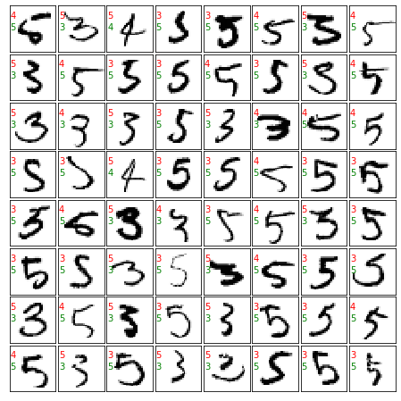

```python
xmis_pred_ = x_test[y_pred_ != y_test]
ymis_pred_ = np.array(y_pred_)[y_pred_ != y_test]
tmp = y_test[y_pred_ != y_test]

fig = plt.figure(figsize=(6, 6))
fig.subplots_adjust(left=0, right=1, bottom=0, top=1, hspace=0.05, wspace=0.05)

for i in range(64):
    ax = fig.add_subplot(8, 8, i + 1, xticks=[], yticks=[])
    ax.imshow(xmis_pred_[i].reshape(28,28), cmap='Greys', interpolation='nearest')
    ax.text(0, 7, str(ymis_pred_[i]) ,color='r')
    ax.text(0, 14, str(tmp[i]) ,color='g')
```

### Take a Closer Look at Each Label

We define a confusion function to visualize the true label/prediction into a matrix.

```python
def confusion(y_test, y_pred):
    confusion_matrix = np.zeros(9).reshape(3,3)

    for i in range(len(y_test)):
        if y_pred[i] == y_test[i] and y_test[i] == 3:
            confusion_matrix[0][0] += 1
        elif y_test[i] == 3 and y_pred[i] == 4:
            confusion_matrix[0][1] += 1
        elif y_test[i] == 3 and y_pred[i] == 5:
            confusion_matrix[0][2] += 1
        elif y_test[i] == 4 and y_pred[i] == 3:
            confusion_matrix[1][0] += 1
        elif y_pred[i] == y_test[i] and y_test[i] == 4:
            confusion_matrix[1][1] += 1
        elif y_test[i] == 4 and y_pred[i] == 5:
            confusion_matrix[1][2] += 1
        elif y_test[i] == 5 and y_pred[i] == 3:
            confusion_matrix[2][0] += 1
        elif y_test[i] == 5 and y_pred[i] == 4:
            confusion_matrix[2][1] += 1
        elif y_pred[i] == y_test[i] and y_test[i] == 5:
            confusion_matrix[2][2] += 1

    confusion_prob = []
    for i in range(3):
        confusion_prob.append(1/sum(y_test == i+3) * confusion_matrix[i])

    return confusion_matrix, confusion_prob
```

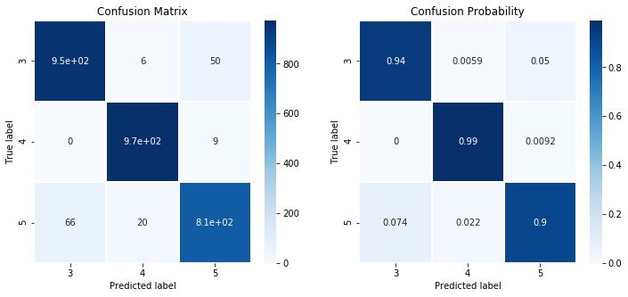

```python
plt.figure(figsize=(12, 5))
labels = [3, 4, 5]
plt.subplot(1,2,1)
y_confusion_ = confusion(y_test, y_pred_)
ax = sns.heatmap(y_confusion_[0], linewidth=1, annot=True, xticklabels=labels, yticklabels = labels,
                cmap="Blues")
b, t = plt.ylim()
b += 0.5
t -= 0.5
plt.ylim(b, t)
plt.ylabel('True label')
plt.xlabel('Predicted label')
plt.title('Confusion Matrix')
plt.subplot(1,2,2)
ax = sns.heatmap(y_confusion_[1], linewidth=1, annot=True, xticklabels=labels, yticklabels = labels,
                cmap="Blues")
b, t = plt.ylim()
b += 0.5
t -= 0.5
plt.ylim(b, t)
plt.ylabel('True label')
plt.xlabel('Predicted label')
plt.title('Confusion Probability')
plt.show()
```